# R 통계

# 통계분석

## 1.상관분석

#### (쌍으로 관찰된 두 변수 X,Y간의 관련성을 분석하는 것)

##### 분석절차

- 1. 눈으로 변수관계를 확인하는 산점도의 작성
- 2. 하나의 수치로 변수간의 직선관계를 나타내는 상관계수를 구한다.:cor(x,y)
- 3. 회귀식의 적합을 통하여 두 변수간의 관계를 함수로 찾는 것.(회귀분석을 실시하기 전에 실시하는 중요한 과정)
- 4. 회귀식의 유용성을 평가한다.

```r
#install.packages("Hmisc")
library(Hmisc)
data(mtcars)
mtcars
```

```
##                      mpg cyl  disp  hp drat    wt  qsec vs am gear carb
## Mazda RX4           21.0   6 160.0 110 3.90 2.620 16.46  0  1    4    4
## Mazda RX4 Wag       21.0   6 160.0 110 3.90 2.875 17.02  0  1    4    4
## Datsun 710          22.8   4 108.0  93 3.85 2.320 18.61  1  1    4    1
## Hornet 4 Drive      21.4   6 258.0 110 3.08 3.215 19.44  1  0    3    1
## Hornet Sportabout   18.7   8 360.0 175 3.15 3.440 17.02  0  0    3    2
## Valiant             18.1   6 225.0 105 2.76 3.460 20.22  1  0    3    1
## Duster 360          14.3   8 360.0 245 3.21 3.570 15.84  0  0    3    4
## Merc 240D           24.4   4 146.7  62 3.69 3.190 20.00  1  0    4    2
## Merc 230            22.8   4 140.8  95 3.92 3.150 22.90  1  0    4    2
## Merc 280            19.2   6 167.6 123 3.92 3.440 18.30  1  0    4    4
## Merc 280C           17.8   6 167.6 123 3.92 3.440 18.90  1  0    4    4
## Merc 450SE          16.4   8 275.8 180 3.07 4.070 17.40  0  0    3    3
## Merc 450SL          17.3   8 275.8 180 3.07 3.730 17.60  0  0    3    3
## Merc 450SLC         15.2   8 275.8 180 3.07 3.780 18.00  0  0    3    3
## Cadillac Fleetwood  10.4   8 472.0 205 2.93 5.250 17.98  0  0    3    4
## Lincoln Continental 10.4   8 460.0 215 3.00 5.424 17.82  0  0    3    4
## Chrysler Imperial   14.7   8 440.0 230 3.23 5.345 17.42  0  0    3    4
## Fiat 128            32.4   4  78.7  66 4.08 2.200 19.47  1  1    4    1
## Honda Civic         30.4   4  75.7  52 4.93 1.615 18.52  1  1    4    2
## Toyota Corolla      33.9   4  71.1  65 4.22 1.835 19.90  1  1    4    1
## Toyota Corona       21.5   4 120.1  97 3.70 2.465 20.01  1  0    3    1
## Dodge Challenger    15.5   8 318.0 150 2.76 3.520 16.87  0  0    3    2
## AMC Javelin         15.2   8 304.0 150 3.15 3.435 17.30  0  0    3    2
## Camaro Z28          13.3   8 350.0 245 3.73 3.840 15.41  0  0    3    4
## Pontiac Firebird    19.2   8 400.0 175 3.08 3.845 17.05  0  0    3    2
## Fiat X1-9           27.3   4  79.0  66 4.08 1.935 18.90  1  1    4    1
## Porsche 914-2       26.0   4 120.3  91 4.43 2.140 16.70  0  1    5    2
## Lotus Europa        30.4   4  95.1 113 3.77 1.513 16.90  1  1    5    2
## Ford Pantera L      15.8   8 351.0 264 4.22 3.170 14.50  0  1    5    4
## Ferrari Dino        19.7   6 145.0 175 3.62 2.770 15.50  0  1    5    6
## Maserati Bora       15.0   8 301.0 335 3.54 3.570 14.60  0  1    5    8
## Volvo 142E          21.4   4 121.0 109 4.11 2.780 18.60  1  1    4    2
```

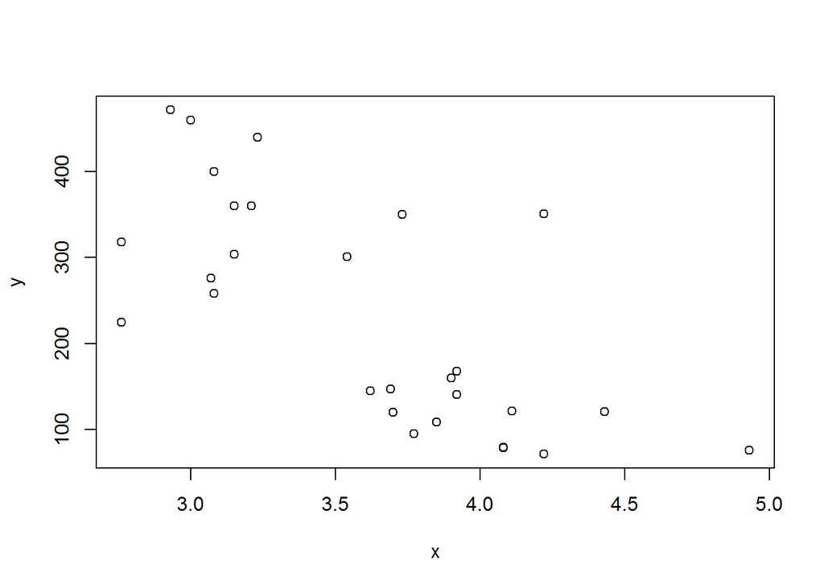

```r
data <- mtcars
x <- data$drat
y <- data$disp
plot(x, y)                              #--- 산점도
```

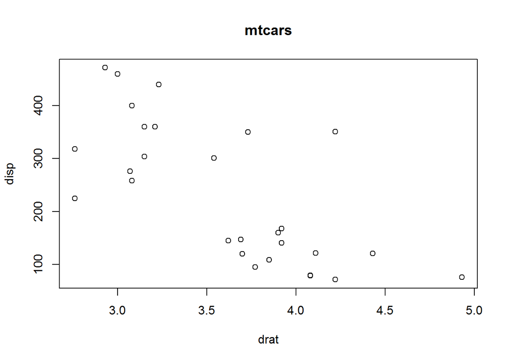

```r
plot(x, y, main="mtcars", xlab="drat", ylab="disp")         #--- 산점도
```

```r
cor(x, y)                               #--- 피어슨 상관계수 (0.6 이상이면 양의 상관)
```

```
## [1] -0.7102139
```

```r
cov(x, y)
```

```
## [1] -47.06402
```

```r
#--- -0.6 보다 작으므로 음의 상관 관계가 있음
cor(data)                               #--- 피어슨 상관계수 (0.6 이상이면 양의 상관)
```

```
##             mpg        cyl       disp         hp        drat         wt
## mpg   1.0000000 -0.8521620 -0.8475514 -0.7761684  0.68117191 -0.8676594
## cyl  -0.8521620  1.0000000  0.9020329  0.8324475 -0.69993811  0.7824958
## disp -0.8475514  0.9020329  1.0000000  0.7909486 -0.71021393  0.8879799
## hp   -0.7761684  0.8324475  0.7909486  1.0000000 -0.44875912  0.6587479
## drat  0.6811719 -0.6999381 -0.7102139 -0.4487591  1.00000000 -0.7124406
## wt   -0.8676594  0.7824958  0.8879799  0.6587479 -0.71244065  1.0000000
## qsec  0.4186840 -0.5912421 -0.4336979 -0.7082234  0.09120476 -0.1747159
## vs    0.6640389 -0.8108118 -0.7104159 -0.7230967  0.44027846 -0.5549157
## am    0.5998324 -0.5226070 -0.5912270 -0.2432043  0.71271113 -0.6924953
## gear  0.4802848 -0.4926866 -0.5555692 -0.1257043  0.69961013 -0.5832870
## carb -0.5509251  0.5269883  0.3949769  0.7498125 -0.09078980  0.4276059
##             qsec         vs          am       gear        carb
## mpg   0.41868403  0.6640389  0.59983243  0.4802848 -0.55092507
## cyl  -0.59124207 -0.8108118 -0.52260705 -0.4926866  0.52698829
## disp -0.43369788 -0.7104159 -0.59122704 -0.5555692  0.39497686
## hp   -0.70822339 -0.7230967 -0.24320426 -0.1257043  0.74981247
## drat  0.09120476  0.4402785  0.71271113  0.6996101 -0.09078980
## wt   -0.17471588 -0.5549157 -0.69249526 -0.5832870  0.42760594
## qsec  1.00000000  0.7445354 -0.22986086 -0.2126822 -0.65624923
## vs    0.74453544  1.0000000  0.16834512  0.2060233 -0.56960714
## am   -0.22986086  0.1683451  1.00000000  0.7940588  0.05753435
## gear -0.21268223  0.2060233  0.79405876  1.0000000  0.27407284
## carb -0.65624923 -0.5696071  0.05753435  0.2740728  1.00000000
```

```r
cov(data)                               #--- 공분산, 0이면 독립
```

```
##              mpg         cyl        disp          hp         drat
## mpg    36.324103  -9.1723790  -633.09721 -320.732056   2.19506351
## cyl    -9.172379   3.1895161   199.66028  101.931452  -0.66836694
## disp -633.097208 199.6602823 15360.79983 6721.158669 -47.06401915
## hp   -320.732056 101.9314516  6721.15867 4700.866935 -16.45110887
## drat    2.195064  -0.6683669   -47.06402  -16.451109   0.28588135
## wt     -5.116685   1.3673710   107.68420   44.192661  -0.37272073
## qsec    4.509149  -1.8868548   -96.05168  -86.770081   0.08714073
## vs      2.017137  -0.7298387   -44.37762  -24.987903   0.11864919
## am      1.803931  -0.4657258   -36.56401   -8.320565   0.19015121
## gear    2.135685  -0.6491935   -50.80262   -6.358871   0.27598790
## carb   -5.363105   1.5201613    79.06875   83.036290  -0.07840726
##               wt         qsec           vs           am        gear
## mpg   -5.1166847   4.50914919   2.01713710   1.80393145   2.1356855
## cyl    1.3673710  -1.88685484  -0.72983871  -0.46572581  -0.6491935
## disp 107.6842040 -96.05168145 -44.37762097 -36.56401210 -50.8026210
## hp    44.1926613 -86.77008065 -24.98790323  -8.32056452  -6.3588710
## drat  -0.3727207   0.08714073   0.11864919   0.19015121   0.2759879
## wt     0.9573790  -0.30548161  -0.27366129  -0.33810484  -0.4210806
## qsec  -0.3054816   3.19316613   0.67056452  -0.20495968  -0.2804032
## vs    -0.2736613   0.67056452   0.25403226   0.04233871   0.0766129
## am    -0.3381048  -0.20495968   0.04233871   0.24899194   0.2923387
## gear  -0.4210806  -0.28040323   0.07661290   0.29233871   0.5443548
## carb   0.6757903  -1.89411290  -0.46370968   0.04637097   0.3266129
##             carb
## mpg  -5.36310484
## cyl   1.52016129
## disp 79.06875000
## hp   83.03629032
## drat -0.07840726
## wt    0.67579032
## qsec -1.89411290
## vs   -0.46370968
## am    0.04637097
## gear  0.32661290
## carb  2.60887097
```

```r
rcorr(x, y, type="spearman")
```

```
##       x     y
## x  1.00 -0.68
## y -0.68  1.00
##
## n= 32
##
##
## P
##   x  y
## x     0
## y  0
```

```r
rcorr(as.matrix(data), type="spearman")  #--- 스피어만 상관계수, type = spearman | pearson
```

```
##        mpg   cyl  disp    hp  drat    wt  qsec    vs    am  gear  carb
## mpg   1.00 -0.91 -0.91 -0.89  0.65 -0.89  0.47  0.71  0.56  0.54 -0.66
## cyl  -0.91  1.00  0.93  0.90 -0.68  0.86 -0.57 -0.81 -0.52 -0.56  0.58
## disp -0.91  0.93  1.00  0.85 -0.68  0.90 -0.46 -0.72 -0.62 -0.59  0.54
## hp   -0.89  0.90  0.85  1.00 -0.52  0.77 -0.67 -0.75 -0.36 -0.33  0.73
## drat  0.65 -0.68 -0.68 -0.52  1.00 -0.75  0.09  0.45  0.69  0.74 -0.13
## wt   -0.89  0.86  0.90  0.77 -0.75  1.00 -0.23 -0.59 -0.74 -0.68  0.50
## qsec  0.47 -0.57 -0.46 -0.67  0.09 -0.23  1.00  0.79 -0.20 -0.15 -0.66
## vs    0.71 -0.81 -0.72 -0.75  0.45 -0.59  0.79  1.00  0.17  0.28 -0.63
## am    0.56 -0.52 -0.62 -0.36  0.69 -0.74 -0.20  0.17  1.00  0.81 -0.06
## gear  0.54 -0.56 -0.59 -0.33  0.74 -0.68 -0.15  0.28  0.81  1.00  0.11
## carb -0.66  0.58  0.54  0.73 -0.13  0.50 -0.66 -0.63 -0.06  0.11  1.00
##
## n= 32
##
##
## P
##      mpg    cyl    disp   hp     drat   wt     qsec   vs     am     gear
## mpg         0.0000 0.0000 0.0000 0.0000 0.0000 0.0071 0.0000 0.0008 0.0013
## cyl  0.0000        0.0000 0.0000 0.0000 0.0000 0.0006 0.0000 0.0022 0.0008
## disp 0.0000 0.0000        0.0000 0.0000 0.0000 0.0081 0.0000 0.0001 0.0003
## hp   0.0000 0.0000 0.0000        0.0023 0.0000 0.0000 0.0000 0.0416 0.0639
## drat 0.0000 0.0000 0.0000 0.0023        0.0000 0.6170 0.0102 0.0000 0.0000
## wt   0.0000 0.0000 0.0000 0.0000 0.0000        0.2148 0.0004 0.0000 0.0000
## qsec 0.0071 0.0006 0.0081 0.0000 0.6170 0.2148        0.0000 0.2644 0.4182
## vs   0.0000 0.0000 0.0000 0.0000 0.0102 0.0004 0.0000        0.3570 0.1170
## am   0.0008 0.0022 0.0001 0.0416 0.0000 0.0000 0.2644 0.3570        0.0000
## gear 0.0013 0.0008 0.0003 0.0639 0.0000 0.0000 0.4182 0.1170 0.0000
## carb 0.0000 0.0005 0.0014 0.0000 0.4947 0.0036 0.0000 0.0000 0.7264 0.5312
##      carb
## mpg  0.0000
## cyl  0.0005
## disp 0.0014
## hp   0.0000
## drat 0.4947
## wt   0.0036
## qsec 0.0000
## vs   0.0000
## am   0.7264
## gear 0.5312
## carb
```

```r
rcorr(as.matrix(data), type="spearman")$r
```

```
##             mpg        cyl       disp         hp        drat         wt
## mpg   1.0000000 -0.9108013 -0.9088824 -0.8946646  0.65145546 -0.8864220
## cyl  -0.9108013  1.0000000  0.9276516  0.9017909 -0.67888117  0.8577282
## disp -0.9088824  0.9276516  1.0000000  0.8510426 -0.68359208  0.8977064
## hp   -0.8946646  0.9017909  0.8510426  1.0000000 -0.52012497  0.7746767
## drat  0.6514555 -0.6788812 -0.6835921 -0.5201250  1.00000000 -0.7503904
## wt   -0.8864220  0.8577282  0.8977064  0.7746767 -0.75039041  1.0000000
## qsec  0.4669358 -0.5723509 -0.4597818 -0.6666060  0.09186863 -0.2254012
## vs    0.7065968 -0.8137890 -0.7236643 -0.7515934  0.44745746 -0.5870162
## am    0.5620057 -0.5220712 -0.6240677 -0.3623275  0.68657076 -0.7377126
## gear  0.5427816 -0.5643105 -0.5944703 -0.3314016  0.74481618 -0.6761284
## carb -0.6574976  0.5800680  0.5397781  0.7333794 -0.12522294  0.4998120
##             qsec         vs          am       gear        carb
## mpg   0.46693575  0.7065968  0.56200570  0.5427816 -0.65749764
## cyl  -0.57235092 -0.8137890 -0.52207118 -0.5643105  0.58006799
## disp -0.45978177 -0.7236643 -0.62406766 -0.5944703  0.53977805
## hp   -0.66660601 -0.7515934 -0.36232755 -0.3314016  0.73337936
## drat  0.09186863  0.4474575  0.68657076  0.7448162 -0.12522294
## wt   -0.22540121 -0.5870162 -0.73771262 -0.6761284  0.49981204
## qsec  1.00000000  0.7915715 -0.20333211 -0.1481997 -0.65871811
## vs    0.79157150  1.0000000  0.16834512  0.2826617 -0.63369483
## am   -0.20333211  0.1683451  1.00000000  0.8076880 -0.06436525
## gear -0.14819968  0.2826617  0.80768800  1.0000000  0.11488698
## carb -0.65871811 -0.6336948 -0.06436525  0.1148870  1.00000000
```

```r
#--- 학생별 과목별 등수
korean <- c(85,75,65,78,59,60,90,100,99,91,70)
math   <- c(80,60,75,40,50,64,70,78,90,98,50)
english<- c(80,70,69,79,80,95,98,97,67,80,59)
science<- c(90,100,50,80,67,89,60,79,89,80,100)
test<-data.frame(korean,math,english,science)

test
```

```
##    korean math english science
## 1      85   80      80      90
## 2      75   60      70     100
## 3      65   75      69      50
## 4      78   40      79      80
## 5      59   50      80      67
## 6      60   64      95      89
## 7      90   70      98      60
## 8     100   78      97      79
## 9      99   90      67      89
## 10     91   98      80      80
## 11     70   50      59     100
```

```r
rcorr(as.matrix(test), type="pearson")  #--- pearson 상관계수
```

```
##         korean  math english science
## korean    1.00  0.63    0.21    0.10
## math      0.63  1.00    0.12   -0.09
## english   0.21  0.12    1.00   -0.31
## science   0.10 -0.09   -0.31    1.00
##
## n= 11
##
##
## P
##         korean math   english science
## korean         0.0385 0.5418  0.7592
## math    0.0385        0.7289  0.7838
## english 0.5418 0.7289         0.3455
## science 0.7592 0.7838 0.3455
```

```r
rcorr(as.matrix(test), type="pearson")$r
```

```
##            korean        math    english     science
## korean  1.0000000  0.62809354  0.2067901  0.10473597
## math    0.6280935  1.00000000  0.1183436 -0.09383566
## english 0.2067901  0.11834359  1.0000000 -0.31495091
## science 0.1047360 -0.09383566 -0.3149509  1.00000000
```

```r
rcorr(as.matrix(test), type="spearman")  #--- 스피어만 상관계수
```

```
##         korean  math english science
## korean    1.00  0.65    0.20    0.00
## math      0.65  1.00    0.16   -0.09
## english   0.20  0.16    1.00   -0.42
## science   0.00 -0.09   -0.42    1.00
##
## n= 11
##
##
## P
##         korean math   english science
## korean         0.0299 0.5517  1.0000
## math    0.0299        0.6462  0.7937
## english 0.5517 0.6462         0.1926
## science 1.0000 0.7937 0.1926
```

```r
rcorr(as.matrix(test), type="spearman")$r
```

```
##            korean        math    english     science
## korean  1.0000000  0.65148234  0.2018434  0.00000000
## math    0.6514823  1.00000000  0.1563256 -0.08945049
## english 0.2018434  0.15632556  1.0000000 -0.42494339
## science 0.0000000 -0.08945049 -0.4249434  1.00000000
```

```r
rm(list=ls(all=TRUE))                   #--- 작업 영역에 저장된 데이터 모두 삭제
```

## 2.상관분석

### 상관분석 실습

- 상관분석 : 두 변수간 선형적 관계의 강도 (인과관계 X)

```r
### 1. 데이터 파일 불러오기 ###
#moving_pop = read.csv ("data/moving_pop2.csv", header=TRUE)

### 2. 데이터 탐색 ###
#moving_pop2=moving_pop[1:5000,]
#head (moving_pop2)

  # 지역 / 주구분 / 시간대 / 날씨 / 성별 / 연령별 / 유동인구수
  # 원본 데이터 23,000개 행임.

### 3. 상관분석 ###
#  cor(남자합계,여자합계)
    #단순한 상관계수 표시
    #0.8400031

#  cor.test(남자합계,여자합계)
    #상관계수가 0이라는 귀무가설을 기각

#  plot(남자합계,여자합계)

#  class (남자합계)
#  class (여자10대)

#  여자10대=as.numeric(여자10대)
#  남자50대=as.numeric(남자50대)

#  cor(여자10대,남자50대)
#  cor.test(여자10대,남자50대)
#  plot(여자10대,남자50대)

#  여자50대=as.numeric(여자50대)
#  남자10대=as.numeric(남자10대)
#  cor(여자50대,남자10대)
#  cor.test(여자50대,남자10대)
#  plot(여자50대,남자10대)
#  plot(남자10대,여자10대)

#  cor(X50대합계,X50대합계) #동일변수간 상관계수는 1
#  cor.test(X10대합계,X20대합계)


#  주중합계=subset(moving_pop2, select=전체합계, subset=(주구분=="주중"))
#  주말합계=subset(moving_pop2, select=전체합계, subset=(주구분=="주말"))

#  class (주중합계)

#  주중합계=as.vector(as.matrix(주중합계))
#  주말합계=as.vector(as.matrix(주말합계))

#  length(주중합계)
#  length(주말합계)
#  cor (주중합계,주말합계)
```

### 3. 분석가설 설정

- 참고 > 통계분석방법 설명 - http://blog.naver.com/PostView.nhn?blogId=gracestock_1&logNo=120200450793&categoryNo=12&parentCategoryNo=0&viewDate=&currentPage=1&postListTopCurrentPage=1
- 1. 지역별 유동인구수는 차이
- 2. 주중/주말 구분에 따른 유동인구수 차이
- 3. 시간대별 유동인구수 차이
- 4. 날씨별 유동인구수 차이
- 5. 성별 유동인구수 차이
- 6. 연령대별 유동인구수 차이

## 3.분산분석

### 4. 분산분석 (ANOVA)

#분산분석 : 3개 이상의 요인의 차이를 검정 (표본이 정규분포를 따를때 수행가능)

```
# 1) 데이터 정규성 검정 - 정규분포에 가까운 경우 (p값 < 0.05) 분산분석 활용 가능
#                       - 정규뷴포를 따르지 않는다면 kruskal-wallis검정 수행

out=lm(전체합계~조사번호)
shapiro.test(resid(out))

# 2) 지역별 유동인구수는 차이는? 분산분석 진행
out_place= aov(전체합계~조사번호)
summary (out_place) #p값 < 0.001 따라서 지역 변수 유의미

# 3) 주중/주말 구분에 따른 유동인구 차이는
out_week=aov(전체합계~주구분)
summary (out_week) #p값 0.153 (>0.05) 따라서 주중/주말변수 무의미

# 3) 날씨별 구분에 따른 유동인구 차이는
out_weather=aov(전체합계~날씨)
summary (out_weather) #p값 0.937 (>0.05) 따라서 날씨 무의미

# 4) 시간별 구분에 따른 유동인구 차이는
out_time=aov(전체합계~시간대)
summary (out_time) #p값 < 0.001 (>0.05) 따라서 시간대 변수 유의미
```

## 4.회귀분석

### —————————————————————————–

### 회귀분석(주어진 자료를 통하여 변수간의 함수관계를 밝히고 이 함수관계를 이용하여 독립변수값에 대응되는 종속변수의 값을 ‘예측’ 또는 ’설명’하는 분석 방법이다. 잔차 분석이라고도 한다: 종속변수와 독립변수와의 관계를 밝히는 통계모형에서 모형에 의하여 추정된 종속변수의 값과 실제 관찰된 종속변수 값과의 차이 이다. 이 차이는 오차(error)로도 해석된다(통계모형이 설명하지 못하는 불확실성 정보이다))

### —————————————————————————–

```r
set.seed(2)                             #--- 난수의 seed 값 지정
x <- runif(10, 0, 11)                   #--- 0 ~ 11, 10개의 난수 생성 (Uniform)
y <- runif(10, 11, 20)                  #--- 11 ~ 20, 10개의 난수 생성 (Uniform)
data <- data.frame(x, y)
data
```

```
##            x        y
## 1   2.033705 15.97407
## 2   7.726114 13.15005
## 3   6.306590 17.84462
## 4   1.848571 12.62738
## 5  10.382233 14.64754
## 6  10.378225 18.68194
## 7   1.420749 19.78759
## 8   9.167937 13.03243
## 9   5.148204 15.00328
## 10  6.049821 11.67481
```

```r
lm (y ~ x, data=data)                   #--- 단순 회귀분석
```

```
##
## Call:
## lm(formula = y ~ x, data = data)
##
## Coefficients:
## (Intercept)            x
##    15.82328     -0.09608
```

```r
#--- 회귀식 : y = 15.82328 - 0.09608 * x

set.seed(2)                             #--- 난수의 seed 값 지정
y <- runif(10, -10, 20)                 #--- 난수 생성
u <- runif(10, 0, 11)                   #--- 난수 생성
v <- runif(10, 11, 20)                  #--- 난수 생성
w <- runif(10, 1, 30)                   #--- 난수 생성
(data <- data.frame(y, u, v, w))
```

```
##            y          u        v         w
## 1  -4.453532  6.0794147 16.95709  1.302021
## 2  11.071221  2.6278424 14.48795  5.774625
## 3   7.199790  8.3656464 18.53200 24.495572
## 4  -4.958442  1.9890211 12.35451 26.196970
## 5  18.315180  4.4581040 14.12545 15.914171
## 6  18.304249  9.3890330 15.39896 19.188692
## 7  -6.125231 10.7403834 12.34322 25.488441
## 8  15.003464  2.4840801 14.21356  9.261247
## 9   4.040555  4.8929015 19.66380 20.349544
## 10  6.499512  0.8247737 12.19135  5.363623
```

```r
(m <- lm (formula = y ~ u + v + w))     #--- 다중 회귀분석
```

```
##
## Call:
## lm(formula = y ~ u + v + w)
##
## Coefficients:
## (Intercept)            u            v            w
##      3.8503      -0.2090       0.4120      -0.1609
```

```r
#--- 회귀식 : y = 3.8503 - 0.2090 * u + 0.4120 * v - 0.1609 * w

summary(m)
```

[output not shown]

```r
#--- F통계량 : 0.1029
#--- p-value : 0.9554 (유의수준 5% 하에서 0.05보다 크므로 통계적으로 유의하지 않음)
#--- 결정 계수 = 0.04894, 수정 결정 계수 = -0.4266 : 매우 낮은 값으로 회귀식이 데이터를 설명하지 못함

data(ChickWeight, package="datasets")   #--- 식이요법을 적용한 닭
head(ChickWeight)
```

```
##   weight Time Chick Diet
## 1     42    0     1    1
## 2     51    2     1    1
## 3     59    4     1    1
## 4     64    6     1    1
## 5     76    8     1    1
## 6     93   10     1    1
```

```r
data <- ChickWeight[ChickWeight$Chick == 1, ]   #--- 1번 닭의 데이터만 추출
(m <- lm(weight~Time, data=data))
```

```
##
## Call:
## lm(formula = weight ~ Time, data = data)
##
## Coefficients:
## (Intercept)         Time
##      24.465        7.988
```

```r
summary(m)
```

```
##
## Call:
## lm(formula = weight ~ Time, data = data)
##
## Residuals:
##      Min       1Q   Median       3Q      Max
## -14.3202 -11.3081  -0.3444  11.1162  17.5346
##
## Coefficients:
##             Estimate Std. Error t value Pr(>|t|)
## (Intercept)  24.4654     6.7279   3.636  0.00456 **
## Time          7.9879     0.5236  15.255 2.97e-08 ***
## ---
## Signif. codes:  0 '***' 0.001 '**' 0.01 '*' 0.05 '.' 0.1 ' ' 1
##
## Residual standard error: 12.29 on 10 degrees of freedom
## Multiple R-squared:  0.9588, Adjusted R-squared:  0.9547
## F-statistic: 232.7 on 1 and 10 DF,  p-value: 2.974e-08
```

```r
#--- F 통계량 : 232.7
#--- p-value : 0.05보다 작으므로 유의수준 5% 하에서 통계적으로 유의함
#--- 결정 계수 = 0.9588 : 회귀식이 데이터를 96% 정도 설명하고 있음
#--- Pr(>|t|) : 회귀계수들의 p-value, 0.05보다 작으므로 통계적으로 유의함


data(cars, package="datasets")
cars
```

```
##    speed dist
## 1      4    2
## 2      4   10
## 3      7    4
## 4      7   22
## 5      8   16
## 6      9   10
## 7     10   18
## 8     10   26
## 9     10   34
## 10    11   17
## 11    11   28
## 12    12   14
## 13    12   20
## 14    12   24
```

[output cut: 36 more lines]

```r
speed2 <- cars$speed^2
data <- cbind(speed2, cars)
data
```

```
##    speed2 speed dist
## 1      16     4    2
## 2      16     4   10
## 3      49     7    4
## 4      49     7   22
## 5      64     8   16
## 6      81     9   10
## 7     100    10   18
## 8     100    10   26
## 9     100    10   34
## 10    121    11   17
## 11    121    11   28
## 12    144    12   14
## 13    144    12   20
## 14    144    12   24
```

[output cut: 36 more lines]

```r
(m <- lm(dist ~ speed + speed2, data=data))
```

```
##
## Call:
## lm(formula = dist ~ speed + speed2, data = data)
##
## Coefficients:
## (Intercept)        speed       speed2
##     2.47014      0.91329      0.09996
```

```r
summary(m)
```

```
##
## Call:
## lm(formula = dist ~ speed + speed2, data = data)
##
## Residuals:
##     Min      1Q  Median      3Q     Max
## -28.720  -9.184  -3.188   4.628  45.152
##
## Coefficients:
##             Estimate Std. Error t value Pr(>|t|)
## (Intercept)  2.47014   14.81716   0.167    0.868
## speed        0.91329    2.03422   0.449    0.656
## speed2       0.09996    0.06597   1.515    0.136
##
## Residual standard error: 15.18 on 47 degrees of freedom
## Multiple R-squared:  0.6673, Adjusted R-squared:  0.6532
## F-statistic: 47.14 on 2 and 47 DF,  p-value: 5.852e-12
```

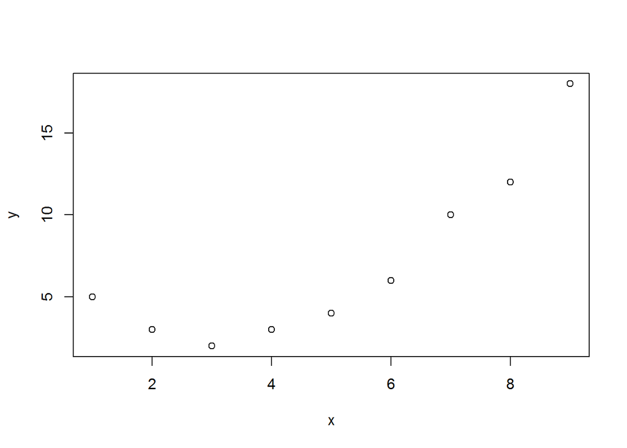

```r
rm(list=ls(all=TRUE))                   #--- 작업 영역에 저장된 데이터 모두 삭제
x <- c(1:9)
y <- c(5, 3, 2, 3, 4, 6, 10, 12, 18)
data <- data.frame(x, y)
plot(data)
```

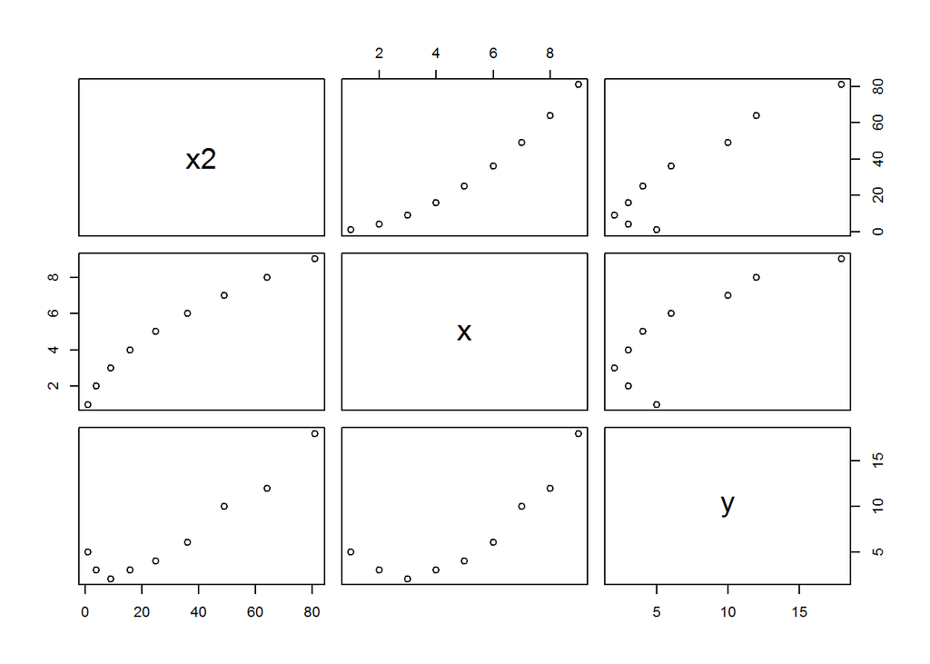

```r
x2 <- x^2
data <- cbind(x2, data)
plot(data)
```

```r
(m <- lm(y ~ x, data=data))
```

```
##
## Call:
## lm(formula = y ~ x, data = data)
##
## Coefficients:
## (Intercept)            x
##      -1.167        1.633
```

```r
summary(m)
```

```
##
## Call:
## lm(formula = y ~ x, data = data)
##
## Residuals:
##     Min      1Q  Median      3Q     Max
## -3.0000 -2.3667 -0.2667  0.9000  4.5333
##
## Coefficients:
##             Estimate Std. Error t value Pr(>|t|)
## (Intercept)  -1.1667     2.2296  -0.523  0.61694
## x             1.6333     0.3962   4.122  0.00445 **
## ---
## Signif. codes:  0 '***' 0.001 '**' 0.01 '*' 0.05 '.' 0.1 ' ' 1
##
## Residual standard error: 3.069 on 7 degrees of freedom
## Multiple R-squared:  0.7083, Adjusted R-squared:  0.6666
## F-statistic: 16.99 on 1 and 7 DF,  p-value: 0.004446
```

```r
(m <- lm(y ~ x + x2, data=data))
```

```
##
## Call:
## lm(formula = y ~ x + x2, data = data)
##
## Coefficients:
## (Intercept)            x           x2
##      7.1667      -2.9121       0.4545
```

```r
summary(m)
```

```
##
## Call:
## lm(formula = y ~ x + x2, data = data)
##
## Residuals:
##     Min      1Q  Median      3Q     Max
## -0.9606 -0.1606  0.0303  0.2242  0.9455
##
## Coefficients:
##             Estimate Std. Error t value Pr(>|t|)
## (Intercept)  7.16667    0.78728   9.103 9.87e-05 ***
## x           -2.91212    0.36149  -8.056 0.000196 ***
## x2           0.45455    0.03526  12.893 1.34e-05 ***
## ---
## Signif. codes:  0 '***' 0.001 '**' 0.01 '*' 0.05 '.' 0.1 ' ' 1
##
## Residual standard error: 0.6187 on 6 degrees of freedom
## Multiple R-squared:  0.9898, Adjusted R-squared:  0.9864
## F-statistic: 292.2 on 2 and 6 DF,  p-value: 1.05e-06
```

```r
rm(list=ls(all=TRUE))                   #--- 작업 영역에 저장된 데이터 모두 삭제
```

#### 변수 선택

```r
#--- 후진제거법으로 변수 선택
x1 <- c(7, 1, 11, 11, 7, 11, 3, 1, 2,21, 1,11, 10)
x2 <- c(26, 29, 56, 31, 52, 55, 71,31, 54, 47, 40, 66, 68)
x3 <- c(6, 15, 8, 8, 6, 9, 17, 22, 18, 4, 23, 9, 8)
x4 <- c(60, 52, 20, 47, 33, 22, 6, 44, 22, 26, 34, 12, 12)
y <- c(78.5, 74.3, 104.3, 87.6, 95.9, 109.2, 102.7, 72.5, 93.1, 115.9, 83.8, 113.3, 109.4)
(data <- data.frame(x1, x2, x3, x4, y))
```

```
##    x1 x2 x3 x4     y
## 1   7 26  6 60  78.5
## 2   1 29 15 52  74.3
## 3  11 56  8 20 104.3
## 4  11 31  8 47  87.6
## 5   7 52  6 33  95.9
## 6  11 55  9 22 109.2
## 7   3 71 17  6 102.7
## 8   1 31 22 44  72.5
## 9   2 54 18 22  93.1
## 10 21 47  4 26 115.9
## 11  1 40 23 34  83.8
## 12 11 66  9 12 113.3
## 13 10 68  8 12 109.4
```

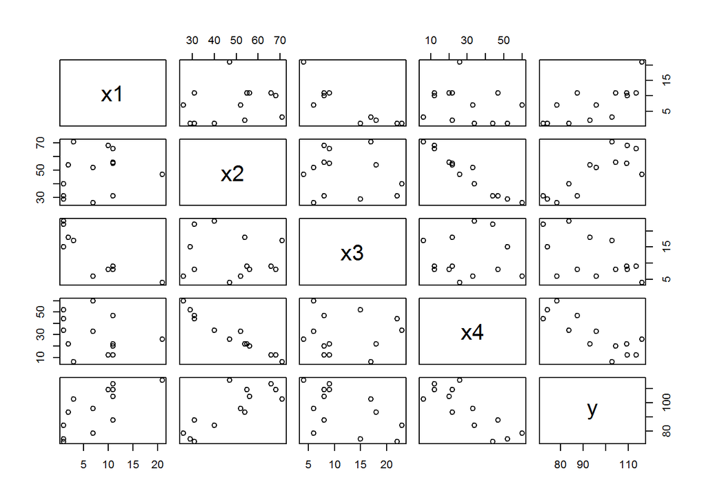

```r
plot(data)
```

```r
m <- lm(y ~ x1 + x2 + x3 + x4, data=data)
summary(m)
```

```
##
## Call:
## lm(formula = y ~ x1 + x2 + x3 + x4, data = data)
##
## Residuals:
##     Min      1Q  Median      3Q     Max
## -3.1750 -1.6709  0.2508  1.3783  3.9254
##
## Coefficients:
##             Estimate Std. Error t value Pr(>|t|)
## (Intercept)  62.4054    70.0710   0.891   0.3991
## x1            1.5511     0.7448   2.083   0.0708 .
## x2            0.5102     0.7238   0.705   0.5009
## x3            0.1019     0.7547   0.135   0.8959
## x4           -0.1441     0.7091  -0.203   0.8441
## ---
## Signif. codes:  0 '***' 0.001 '**' 0.01 '*' 0.05 '.' 0.1 ' ' 1
##
## Residual standard error: 2.446 on 8 degrees of freedom
## Multiple R-squared:  0.9824, Adjusted R-squared:  0.9736
## F-statistic: 111.5 on 4 and 8 DF,  p-value: 4.756e-07
```

```r
#--- x3의 유의수준이 가장 높아, x3 제거

m <- lm(y ~ x1 + x2 + x4, data=data)
summary(m)
```

```
##
## Call:
## lm(formula = y ~ x1 + x2 + x4, data = data)
##
## Residuals:
##     Min      1Q  Median      3Q     Max
## -3.0919 -1.8016  0.2562  1.2818  3.8982
##
## Coefficients:
##             Estimate Std. Error t value Pr(>|t|)
## (Intercept)  71.6483    14.1424   5.066 0.000675 ***
## x1            1.4519     0.1170  12.410 5.78e-07 ***
## x2            0.4161     0.1856   2.242 0.051687 .
## x4           -0.2365     0.1733  -1.365 0.205395
## ---
## Signif. codes:  0 '***' 0.001 '**' 0.01 '*' 0.05 '.' 0.1 ' ' 1
##
## Residual standard error: 2.309 on 9 degrees of freedom
## Multiple R-squared:  0.9823, Adjusted R-squared:  0.9764
## F-statistic: 166.8 on 3 and 9 DF,  p-value: 3.323e-08
```

```r
#--- x4의 유의수준이 가장 높아, x4 제거

m <- lm(y ~ x1 + x2, data=data)
summary(m)
```

```
##
## Call:
## lm(formula = y ~ x1 + x2, data = data)
##
## Residuals:
##    Min     1Q Median     3Q    Max
## -2.893 -1.574 -1.302  1.363  4.048
##
## Coefficients:
##             Estimate Std. Error t value Pr(>|t|)
## (Intercept) 52.57735    2.28617   23.00 5.46e-10 ***
## x1           1.46831    0.12130   12.11 2.69e-07 ***
## x2           0.66225    0.04585   14.44 5.03e-08 ***
## ---
## Signif. codes:  0 '***' 0.001 '**' 0.01 '*' 0.05 '.' 0.1 ' ' 1
##
## Residual standard error: 2.406 on 10 degrees of freedom
## Multiple R-squared:  0.9787, Adjusted R-squared:  0.9744
## F-statistic: 229.5 on 2 and 10 DF,  p-value: 4.407e-09
```

```r
#--- 자동으로 변수 선택
#--- direction : forward, backward, both
#--- 전진선택법으로 변수 선택
step(lm(y ~ 1, data=data), scope=list(lower = ~ 1, upper = ~ x1 + x2 + x3 + x4), direction = "forward")
```

```
## Start:  AIC=71.44
## y ~ 1
##
##        Df Sum of Sq     RSS    AIC
## + x4    1   1831.90  883.87 58.852
## + x2    1   1809.43  906.34 59.178
## + x1    1   1450.08 1265.69 63.519
## + x3    1    776.36 1939.40 69.067
## <none>              2715.76 71.444
##
## Step:  AIC=58.85
## y ~ x4
##
##        Df Sum of Sq    RSS    AIC
## + x1    1    809.10  74.76 28.742
## + x3    1    708.13 175.74 39.853
## <none>              883.87 58.852
## + x2    1     14.99 868.88 60.629
##
## Step:  AIC=28.74
## y ~ x4 + x1
##
##        Df Sum of Sq    RSS    AIC
## + x2    1    26.789 47.973 24.974
## + x3    1    23.926 50.836 25.728
## <none>              74.762 28.742
##
## Step:  AIC=24.97
## y ~ x4 + x1 + x2
##
##        Df Sum of Sq    RSS    AIC
## <none>              47.973 24.974
## + x3    1   0.10909 47.864 26.944
```

```
##
## Call:
## lm(formula = y ~ x4 + x1 + x2, data = data)
##
## Coefficients:
## (Intercept)           x4           x1           x2
##     71.6483      -0.2365       1.4519       0.4161
```

```r
#--- 후진소거법으로 변수 선택
step(lm(y ~ x1 + x2 + x3 + x4, data=data), scope=list(lower = ~ 1, upper = ~ x1 + x2 + x3 + x4), direction = "backward")
```

```
## Start:  AIC=26.94
## y ~ x1 + x2 + x3 + x4
##
##        Df Sum of Sq    RSS    AIC
## - x3    1    0.1091 47.973 24.974
## - x4    1    0.2470 48.111 25.011
## - x2    1    2.9725 50.836 25.728
## <none>              47.864 26.944
## - x1    1   25.9509 73.815 30.576
##
## Step:  AIC=24.97
## y ~ x1 + x2 + x4
##
##        Df Sum of Sq    RSS    AIC
## <none>               47.97 24.974
## - x4    1      9.93  57.90 25.420
## - x2    1     26.79  74.76 28.742
## - x1    1    820.91 868.88 60.629
```

```
##
## Call:
## lm(formula = y ~ x1 + x2 + x4, data = data)
##
## Coefficients:
## (Intercept)           x1           x2           x4
##     71.6483       1.4519       0.4161      -0.2365
```

```r
#--- 단계적방법으로 변수 선택
step(lm(y ~ 1, data=data), scope=list(lower = ~ 1, upper = ~ x1 + x2 + x3 + x4), direction = "both")
```

```
## Start:  AIC=71.44
## y ~ 1
##
##        Df Sum of Sq     RSS    AIC
## + x4    1   1831.90  883.87 58.852
## + x2    1   1809.43  906.34 59.178
## + x1    1   1450.08 1265.69 63.519
## + x3    1    776.36 1939.40 69.067
## <none>              2715.76 71.444
##
## Step:  AIC=58.85
## y ~ x4
##
##        Df Sum of Sq     RSS    AIC
## + x1    1    809.10   74.76 28.742
## + x3    1    708.13  175.74 39.853
## <none>               883.87 58.852
## + x2    1     14.99  868.88 60.629
## - x4    1   1831.90 2715.76 71.444
##
## Step:  AIC=28.74
## y ~ x4 + x1
##
##        Df Sum of Sq     RSS    AIC
## + x2    1     26.79   47.97 24.974
## + x3    1     23.93   50.84 25.728
## <none>                74.76 28.742
## - x1    1    809.10  883.87 58.852
## - x4    1   1190.92 1265.69 63.519
##
## Step:  AIC=24.97
## y ~ x4 + x1 + x2
##
##        Df Sum of Sq    RSS    AIC
## <none>               47.97 24.974
## - x4    1      9.93  57.90 25.420
## + x3    1      0.11  47.86 26.944
## - x2    1     26.79  74.76 28.742
## - x1    1    820.91 868.88 60.629
```

```
##
## Call:
## lm(formula = y ~ x4 + x1 + x2, data = data)
##
## Coefficients:
## (Intercept)           x4           x1           x2
##     71.6483      -0.2365       1.4519       0.4161
```

```r
rm(list=ls(all=TRUE))                   #--- 작업 영역에 저장된 데이터 모두 삭제
```

```r
# 예제] MASS hills 데이터
data(hills, package="MASS")
head(hills)
```

```
##              dist climb   time
## Greenmantle   2.5   650 16.083
## Carnethy      6.0  2500 48.350
## Craig Dunain  6.0   900 33.650
## Ben Rha       7.5   800 45.600
## Ben Lomond    8.0  3070 62.267
## Goatfell      8.0  2866 73.217
```

```r
#--- 전진선택법으로 변수 선택
step(lm(time ~ 1, data=hills), scope=list(lower = ~ 1, upper = ~ dist + climb + time), direction = "forward")
```

```
## Start:  AIC=274.88
## time ~ 1
```

```
##         Df Sum of Sq   RSS    AIC
## + dist   1     71997 13142 211.49
## + climb  1     55205 29934 240.30
## <none>               85138 274.88
##
## Step:  AIC=211.49
## time ~ dist
```

```
##         Df Sum of Sq     RSS    AIC
## + climb  1    6249.7  6891.9 190.90
## <none>               13141.6 211.49
##
## Step:  AIC=190.9
## time ~ dist + climb
```

```
##        Df Sum of Sq    RSS   AIC
## <none>              6891.9 190.9
```

```
##
## Call:
## lm(formula = time ~ dist + climb, data = hills)
##
## Coefficients:
## (Intercept)         dist        climb
##    -8.99204      6.21796      0.01105
```

```r
# 예제2 416Page 참조
```

## 5.시계열분석

### —————————————————————————–

### 시계열분석(시간의 흐름에 따라 관찰되는 값들을 시계열 자료라 한다)

### —————————————————————————–

정상성 : 비정상성인 시계열 자료를 정상성으로 변환하는 작업(통계분석은 추정과 가정검증과 예측이기 때문에) (1). 평균이 일정하다. 즉 모든 시점에 대한 일정한 평균을 가진다., (2)분산도 시점에 의존하지 않는다. (3)공분산은 단지 시차에만 의존하고 실제 어느 지점 t, s에는 의존하지 않는다(?) 비정상성 : 시계열로 분석하기 어려운 자료. 1. 데이터가 정상성 자료인지, 비정상성 자료인지 판단한다.(어떻게 판단?:정상성 판단) 2. 비정상성 시계열 자료를 정상성 시계열 자료로 변환한다. - 방법 : 변환(분산이 일정하지 않을 때), 차분(평균이 일정치 않는 시계열)

자기회귀모형(AR모형) AR(p) : AR(1) 과거 1시점 전까지 영향, AR(2) 과거 2시점 전까지 영향 - 판단방법 : 자기상관함수(ACF), 부분자기함수(PACF)

이동평균모형(MR모형) 1차이동평균모형(MA(1)) 시계열이 같은 시점의 백색잡음과 바로 전 시점의 백색잡음의 결합으로 이뤄진 모형 2차이동평균모형(MA(2)) 시계열이 같은 시점의 백색잡음과 전 시점의 백색잡음. 그리고 시차가 2인 백색잡음의 결합.(시차가2인?)

자기회귀누적이동평균모형(ARIMA(p,d,q)모형) 비정상시계열 모형이다. 즉 ARIMA모형은 차분이나 변환을 통해 AR,MA 이 둘을 합친 ARMA모형으로 정상화 할 수 있다. -> AR,MA는 차분과 변환을 통해, 비정상성 시계열을 정상성으로 변환해 줘야 하는데 ARIMA 모형은 차분도 같이 진행한다.

분해시계열 : 시계열을 분리해 분석하는 방법(영향을 주는 요인), 회귀분석적인 방법을 주로 사용한다. - 종류 : 추세요인, 계절요인, 순환요인, 불규칙요인

```r
#install.packages("TTR")
library(TTR)

#install.packages("forecast")
library(forecast)
###-----------------------------------------------------------------------------
#--- "영국 왕들의 사망시 나이" 분석
data <- c(60, 43, 67, 50, 56, 42, 50, 65, 68, 43,
          65, 34, 47, 34, 49, 41, 13, 35, 53, 56,
          16, 43, 69, 59, 48, 59, 86, 55, 68, 51,
          33, 49, 67, 77, 81, 67, 71, 81, 68, 70,
          77, 56)
#data <- read.table("http://robjhyndman.com/tsdldata/misc/kings.dat", header=TRUE, sep=",",
#                   stringsAsFactors=FALSE, na.strings=c('NIL'),
#                   comment.char="#", encoding="UTF-8")
#data <- scan("http://robjhyndman.com/tsdldata/misc/kings.dat")
#write.table(data, file="data/data.csv", append=FALSE, quote=FALSE, sep=",", row.names=FALSE)
(data <- ts(data))                      #--- 데이터를 시계열 자료 형식으로 변환
```

```
## Time Series:
## Start = 1
## End = 42
## Frequency = 1
##  [1] 60 43 67 50 56 42 50 65 68 43 65 34 47 34 49 41 13 35 53 56 16 43 69
## [24] 59 48 59 86 55 68 51 33 49 67 77 81 67 71 81 68 70 77 56
```

```r
plot(data)                              #--- plot.ts 함수로 시각화
#plot.ts(data)                          #--- plot.ts 함수로 시각화
#--- 비계절성 시계열 자료 : 추세요인과 불규칙 요인으로 구성
#--- 계절요인과 순환요인이 없는 시계열 자료

#현재 데이터의 특정은 비계절성을 띄는 시계열(트랜드(추세)요소, 불규칙 요소 구성)
#SMA는 이동 평균을 구하는 함수로써, 시계열의 트랜드를 보여준다.
library(TTR)
(data03 <- SMA(data, n = 3))            #--- 3년마다 평균을 낸 데이터로 변환
```

```
## Time Series:
## Start = 1
## End = 42
## Frequency = 1
##  [1]       NA       NA 56.66667 53.33333 57.66667 49.33333 49.33333
##  [8] 52.33333 61.00000 58.66667 58.66667 47.33333 48.66667 38.33333
## [15] 43.33333 41.33333 34.33333 29.66667 33.66667 48.00000 41.66667
## [22] 38.33333 42.66667 57.00000 58.66667 55.33333 64.33333 66.66667
## [29] 69.66667 58.00000 50.66667 44.33333 49.66667 64.33333 75.00000
## [36] 75.00000 73.00000 73.00000 73.33333 73.00000 71.66667 67.66667
```

```r
(data08 <- SMA(data, n = 8))            #--- 8년마다 평균을 낸 데이터로 변환
```

```
## Time Series:
## Start = 1
## End = 42
## Frequency = 1
##  [1]     NA     NA     NA     NA     NA     NA     NA 54.125 55.125 55.125
## [11] 54.875 52.875 51.750 50.750 50.625 47.625 40.750 39.750 38.250 41.000
## [21] 37.125 38.250 40.750 43.000 47.375 50.375 54.500 54.375 60.875 61.875
## [31] 57.375 56.125 58.500 60.750 60.125 61.625 62.000 65.750 70.125 72.750
## [41] 74.000 71.375
```

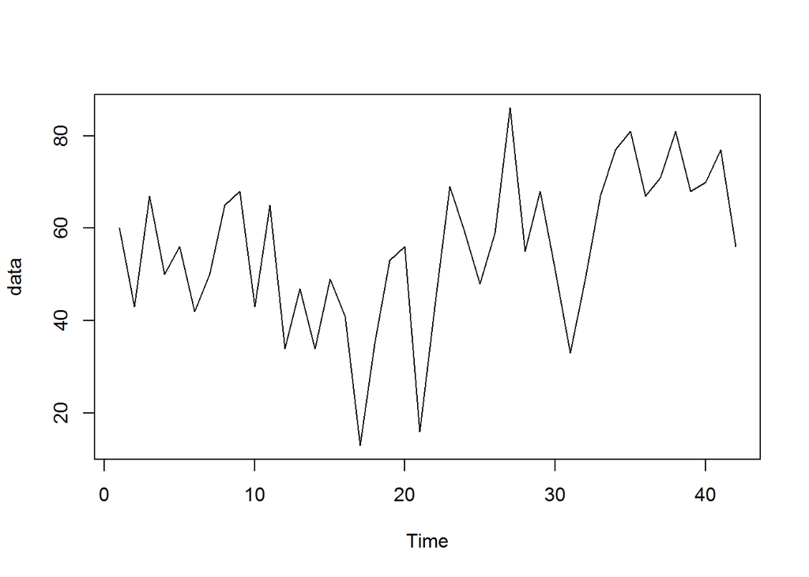

```r
plot(data)
```

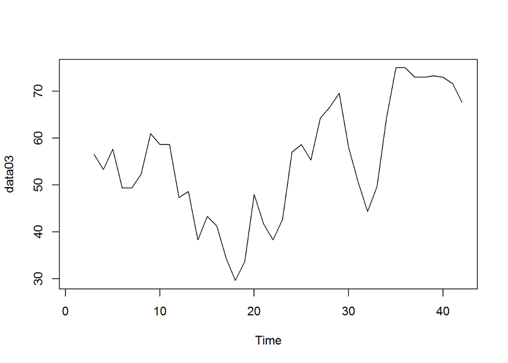

```r
plot(data03)
```

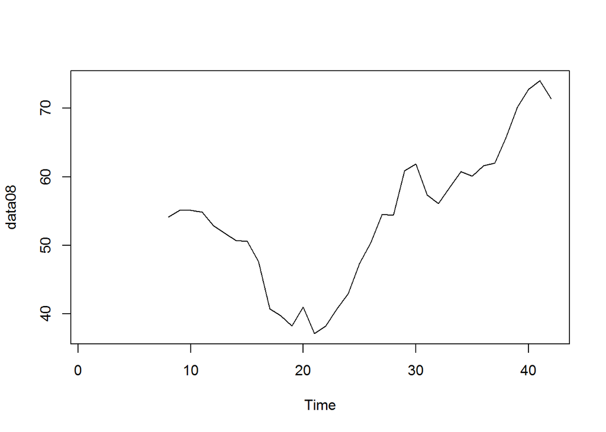

```r
plot(data08)
```

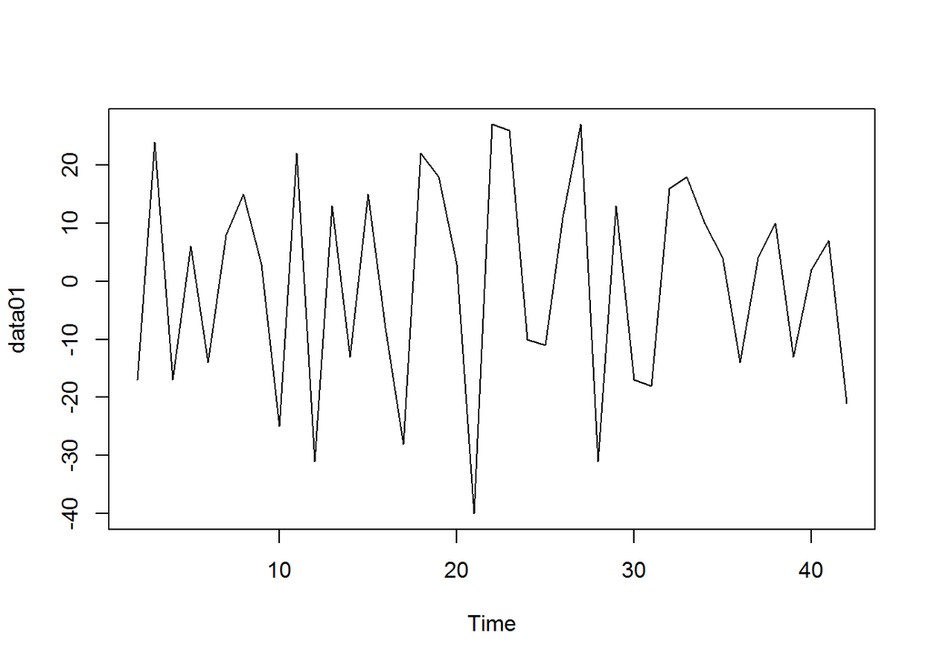

```r
# http://finance.naver.com/item/fchart.nhn?code=035420


#--- 차분 (difference) 데이터의 평균이 일정하지 않아 차분함.
data01 <- diff(data, differences = 1)
plot(data01)                            #--- ARIMA(p, 1, q) 모델
```

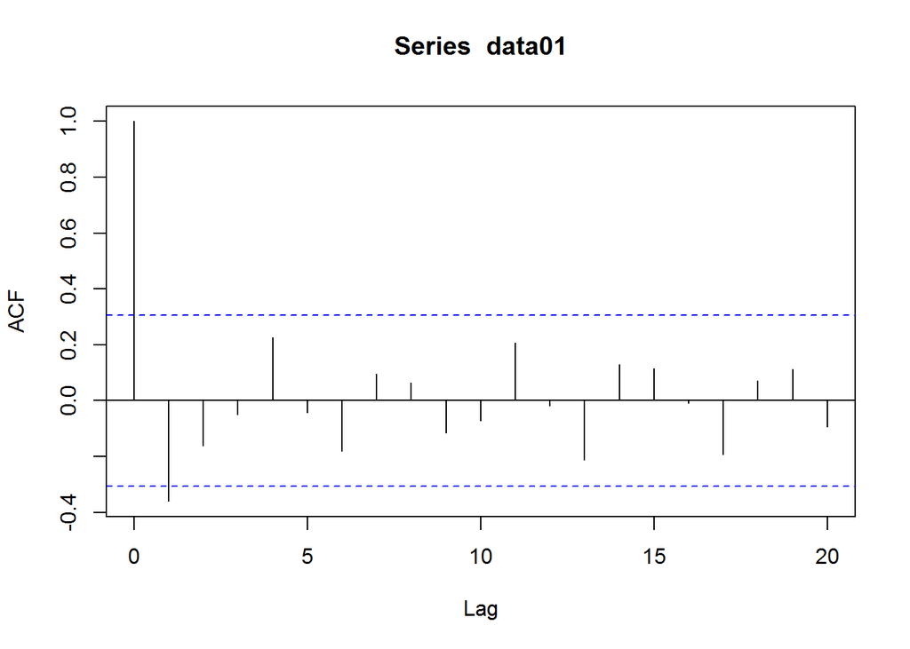

```
##
## Autocorrelations of series 'data01', by lag
##
##      0      1      2      3      4      5      6      7      8      9
##  1.000 -0.360 -0.162 -0.050  0.227 -0.042 -0.181  0.095  0.064 -0.116
##     10     11     12     13     14     15     16     17     18     19
## -0.071  0.206 -0.017 -0.212  0.130  0.114 -0.009 -0.192  0.072  0.113
##     20
## -0.093
```

```r
(acf(data01, lag.max=20))               #--- 자기상관함수(ACF)
```

```r
acf(data01, lag.max=20, plot=FALSE)
```

```
##
## Autocorrelations of series 'data01', by lag
##
##      0      1      2      3      4      5      6      7      8      9
##  1.000 -0.360 -0.162 -0.050  0.227 -0.042 -0.181  0.095  0.064 -0.116
##     10     11     12     13     14     15     16     17     18     19
## -0.071  0.206 -0.017 -0.212  0.130  0.114 -0.009 -0.192  0.072  0.113
##     20
## -0.093
```

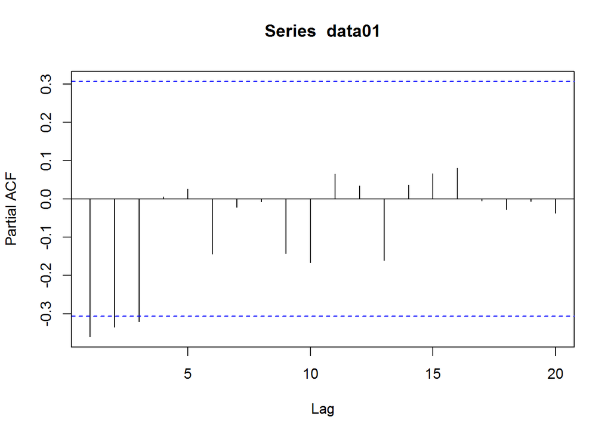

```
##
## Partial autocorrelations of series 'data01', by lag
##
##      1      2      3      4      5      6      7      8      9     10
## -0.360 -0.335 -0.321  0.005  0.025 -0.144 -0.022 -0.007 -0.143 -0.167
##     11     12     13     14     15     16     17     18     19     20
##  0.065  0.034 -0.161  0.036  0.066  0.081 -0.005 -0.027 -0.006 -0.037
```

```r
#--- lag = 0인 지점은 판단에서 제외
#--- lag = 1인 지점을 빼고는 모두 점선 구간 안에 있음
#--- lag = 2에서 절단점을 가짐 -> MA(1) 모형

(pacf(data01, lag.max=20))              #--- 부분자기함수(PACF)
```

```r
#--- lag = 0인 지점은 판단에서 제외
#--- lag = 1, 2, 3에서 점선 구간을 초과하고 음의 값을 가지며
#--- lag = 4에 절단점을 가짐 -> AR(3) 모형
#arma(3,1)

library(forecast)
auto.arima(data)                        #--- 자동으로 최적의 ARIMA 모형을 제시
```

```
## Series: data
## ARIMA(0,1,1)
##
## Coefficients:
##           ma1
##       -0.7218
## s.e.   0.1208
##
## sigma^2 estimated as 236.2:  log likelihood=-170.06
## AIC=344.13   AICc=344.44   BIC=347.56
```

```r
#--- ARIMA(0, 1, 1) 모형 채택

#--- 모수가 적어 가장 간단하고 표현하기 쉬운 MA(1) 모형 선택

#--- 모델 보정 (fitting)
(data02 <- arima(data, order=c(0, 1, 1)))
```

```
##
## Call:
## arima(x = data, order = c(0, 1, 1))
##
## Coefficients:
##           ma1
##       -0.7218
## s.e.   0.1208
##
## sigma^2 estimated as 230.4:  log likelihood = -170.06,  aic = 344.13
```

```r
library(forecast)
(data03 <- forecast.Arima(data02, h=20))#--- 43번째부터 와의 사망 시 나이 예측
```

```
##    Point Forecast    Lo 80    Hi 80    Lo 95     Hi 95
## 43       67.75063 48.29647 87.20479 37.99806  97.50319
## 44       67.75063 47.55748 87.94377 36.86788  98.63338
## 45       67.75063 46.84460 88.65665 35.77762  99.72363
## 46       67.75063 46.15524 89.34601 34.72333 100.77792
## 47       67.75063 45.48722 90.01404 33.70168 101.79958
## 48       67.75063 44.83866 90.66260 32.70979 102.79146
## 49       67.75063 44.20796 91.29330 31.74523 103.75603
## 50       67.75063 43.59372 91.90753 30.80583 104.69543
## 51       67.75063 42.99472 92.50653 29.88974 105.61152
## 52       67.75063 42.40988 93.09138 28.99529 106.50596
## 53       67.75063 41.83823 93.66303 28.12103 107.38023
## 54       67.75063 41.27892 94.22234 27.26564 108.23561
## 55       67.75063 40.73119 94.77007 26.42796 109.07330
## 56       67.75063 40.19434 95.30692 25.60692 109.89433
## 57       67.75063 39.66775 95.83350 24.80158 110.69968
## 58       67.75063 39.15086 96.35039 24.01106 111.49020
## 59       67.75063 38.64315 96.85811 23.23458 112.26668
## 60       67.75063 38.14414 97.35712 22.47141 113.02985
## 61       67.75063 37.65340 97.84786 21.72089 113.78037
## 62       67.75063 37.17054 98.33072 20.98242 114.51884
```

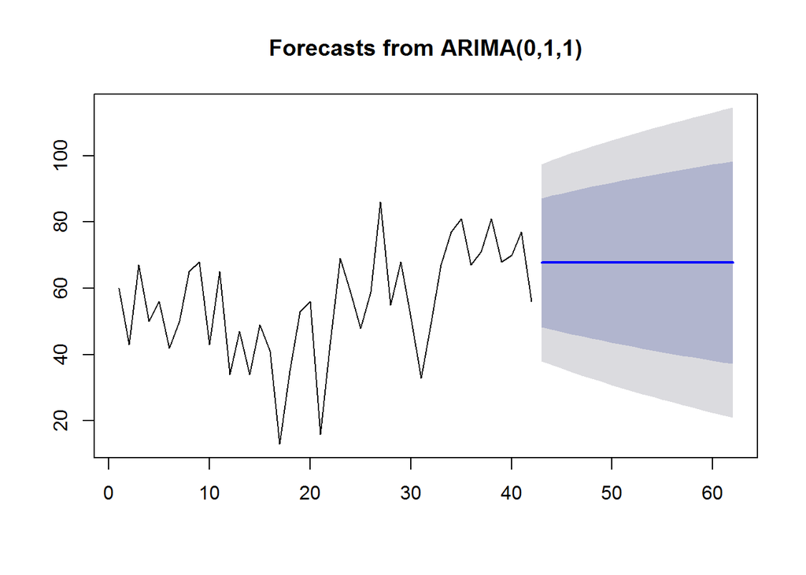

```r
plot(data03)                            #--- 신뢰구간 80%와 95%에서 예측값
```

```r
#plot.forecast(data03)                  #--- 신뢰구간 80%와 95%에서 예측값

rm(list=ls(all=TRUE))                   #--- 작업 영역에 저장된 데이터 모두 삭제
```

```r
###-----------------------------------------------------------------------------
#--- "뉴욕에서 1946년 1월부터 1959년 12월까지 월별 출생자 수" 분석
data <- scan("http://robjhyndman.com/tsdldata/data/nybirths.dat")
(data <- ts(data, frequency=12, start=c(1946, 1)))          #--- 데이터를 시계열 자료 형식으로 변환
```

```
##         Jan    Feb    Mar    Apr    May    Jun    Jul    Aug    Sep    Oct
## 1946 26.663 23.598 26.931 24.740 25.806 24.364 24.477 23.901 23.175 23.227
## 1947 21.439 21.089 23.709 21.669 21.752 20.761 23.479 23.824 23.105 23.110
## 1948 21.937 20.035 23.590 21.672 22.222 22.123 23.950 23.504 22.238 23.142
## 1949 21.548 20.000 22.424 20.615 21.761 22.874 24.104 23.748 23.262 22.907
## 1950 22.604 20.894 24.677 23.673 25.320 23.583 24.671 24.454 24.122 24.252
## 1951 23.287 23.049 25.076 24.037 24.430 24.667 26.451 25.618 25.014 25.110
## 1952 23.798 22.270 24.775 22.646 23.988 24.737 26.276 25.816 25.210 25.199
## 1953 24.364 22.644 25.565 24.062 25.431 24.635 27.009 26.606 26.268 26.462
## 1954 24.657 23.304 26.982 26.199 27.210 26.122 26.706 26.878 26.152 26.379
## 1955 24.990 24.239 26.721 23.475 24.767 26.219 28.361 28.599 27.914 27.784
## 1956 26.217 24.218 27.914 26.975 28.527 27.139 28.982 28.169 28.056 29.136
## 1957 26.589 24.848 27.543 26.896 28.878 27.390 28.065 28.141 29.048 28.484
## 1958 27.132 24.924 28.963 26.589 27.931 28.009 29.229 28.759 28.405 27.945
## 1959 26.076 25.286 27.660 25.951 26.398 25.565 28.865 30.000 29.261 29.012
##         Nov    Dec
## 1946 21.672 21.870
## 1947 21.759 22.073
## 1948 21.059 21.573
## 1949 21.519 22.025
## 1950 22.084 22.991
## 1951 22.964 23.981
## 1952 23.162 24.707
## 1953 25.246 25.180
## 1954 24.712 25.688
## 1955 25.693 26.881
## 1956 26.291 26.987
## 1957 26.634 27.735
## 1958 25.912 26.619
## 1959 26.992 27.897
```

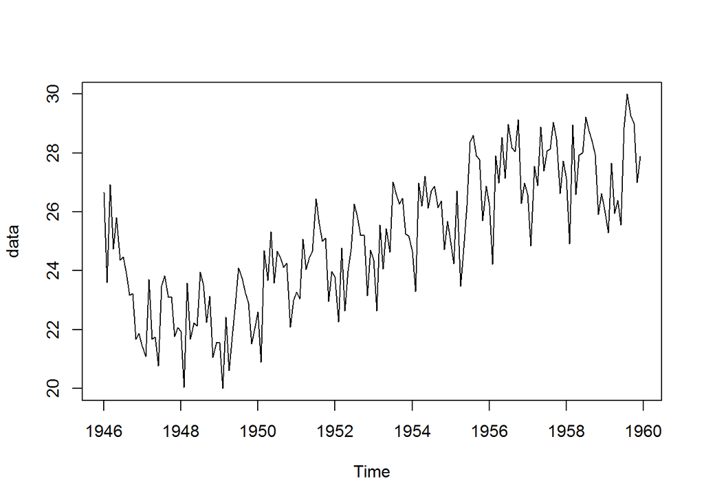

```r
plot(data)                              #--- plot.ts 함수로 시각화
```